# Lab 2

Advanced applied statistics, 2015

## Today

- Mandatory assignment 1
- OVB and logit regression

## Mandatory assignment 1

1. Examine the bivariate and multivariate relationship between gender (female) and political knowledge (polinfo, y ) in Poland. At a minimum, consider the following third variables: age, education, political interest.
2. Investigate also possible parameter heterogeneity in the relationship between gender and political knowledge (using interactions).
3. Illustrate graphically the key results from your analysis, especially where you find indications of heterogeneity in the gender gap.
4. Export your empirical results using an appropriate command (Stata: e.g., outreg2; R: e.g., texreg). Report the results from your regressions in a single table. The table's format and content must conform to the usual standards for such tables.

## MA1, language

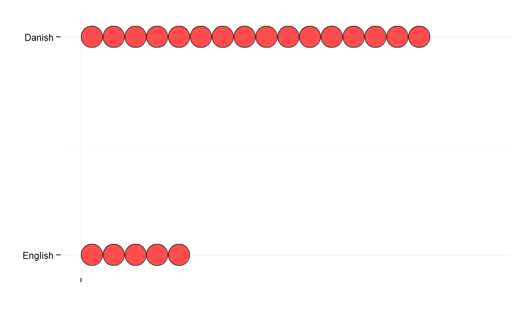

## MA1, overall dissemination

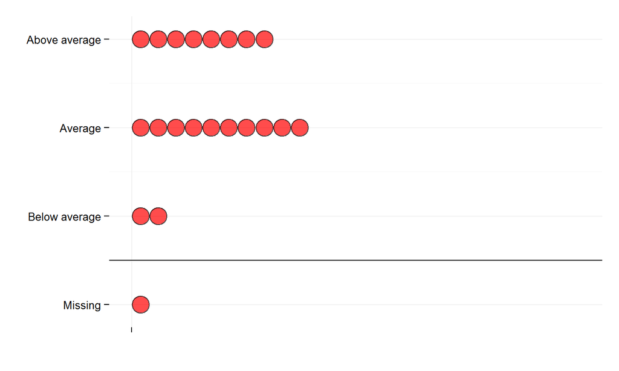

## MA1, overall dissemination

- Remember to have a short introduction and conclusion
- Describe the methods. What are we doing? And why?
- Do everything you are asked to do
  - No need to do more than that

## MA1, substantial interpretation

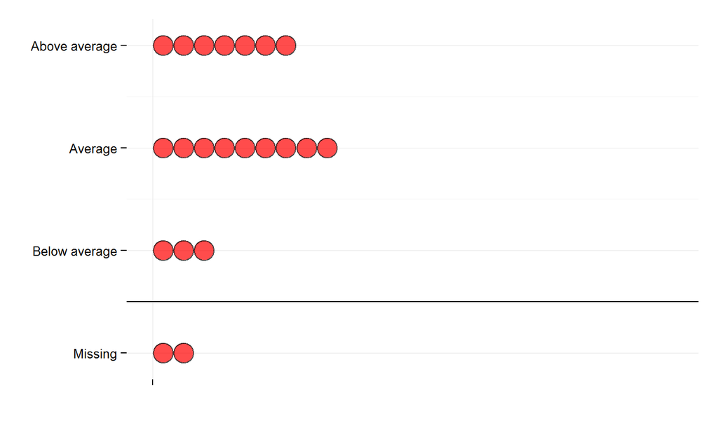

## MA1, substantial interpretation

- Make substantial interpretations!
  - Write and discuss: "Men have, on average, one more correct answer than women."
  - Is that a lot? Maybe, maybe not.
- Make substantial interpretations in **all** analyses

## MA1, reproducibility

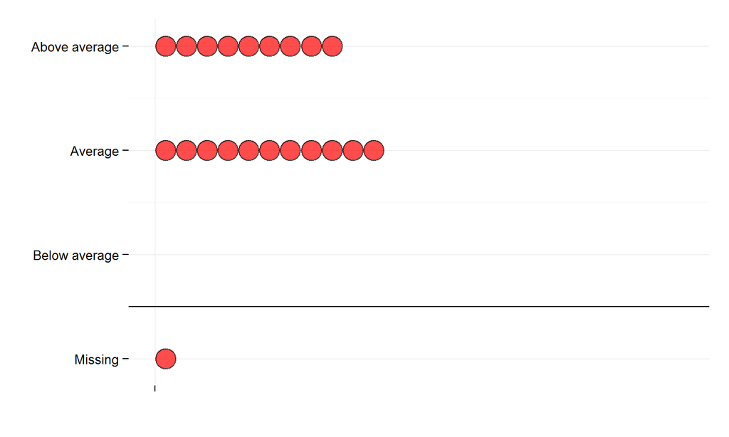

## MA1, reproducibility

- Overall: Great job!
- Make it easy to read
- Be sure to make it all anonymous
  - Also when you load your data set
- Try not to include all your output as code

## MA1, descriptive statistics

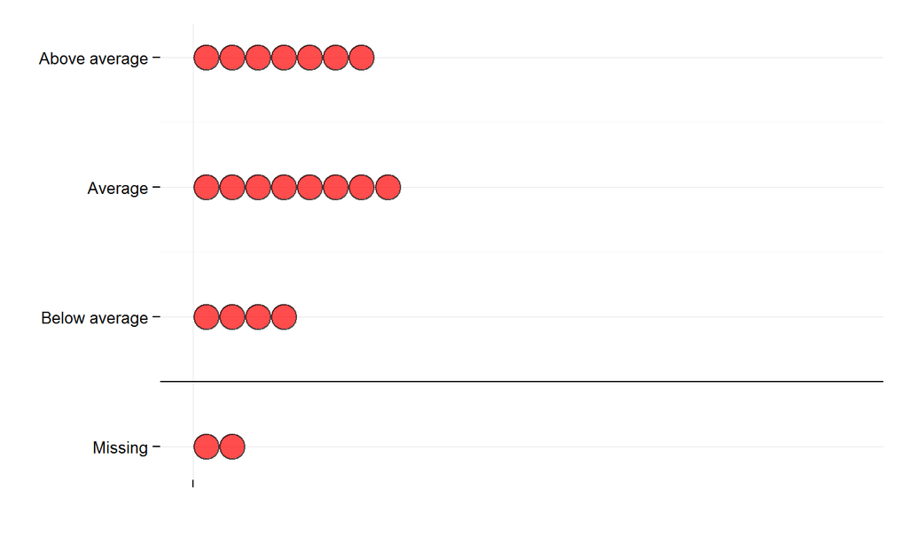

## MA1, descriptive statistics

- Remember mean, standard deviation etc.
- Include as much information as possible

## MA1, bivariate (task 1a)

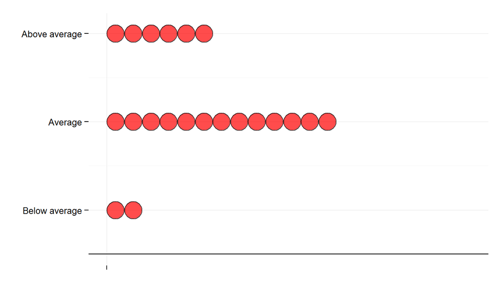

## MA1, bivariate (task 1a)

- t-test or simple regression
  - Same result
- Again: Remember the substantial interpretation

## MA1, multivariate (task 1b)

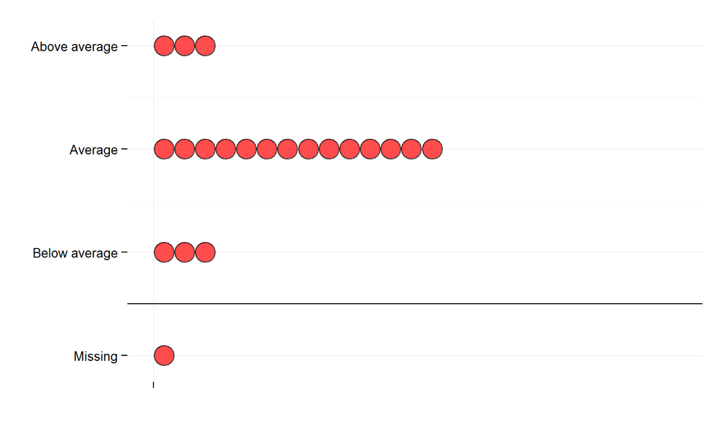

## MA1, multivariate (task 1b)

- Discuss the effect from the bivariate regression in relation to the effect from the multivariate regression.
- Discuss the different predictors (statistically and substantially)

## MA1, interaction (task 2)

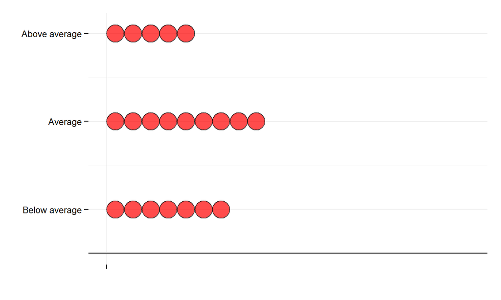

## MA1, interaction (task 2)

- Explain the logic. When and why do you want to include an interaction term? What is happening when we do it?

## MA1, visualization (task 3)

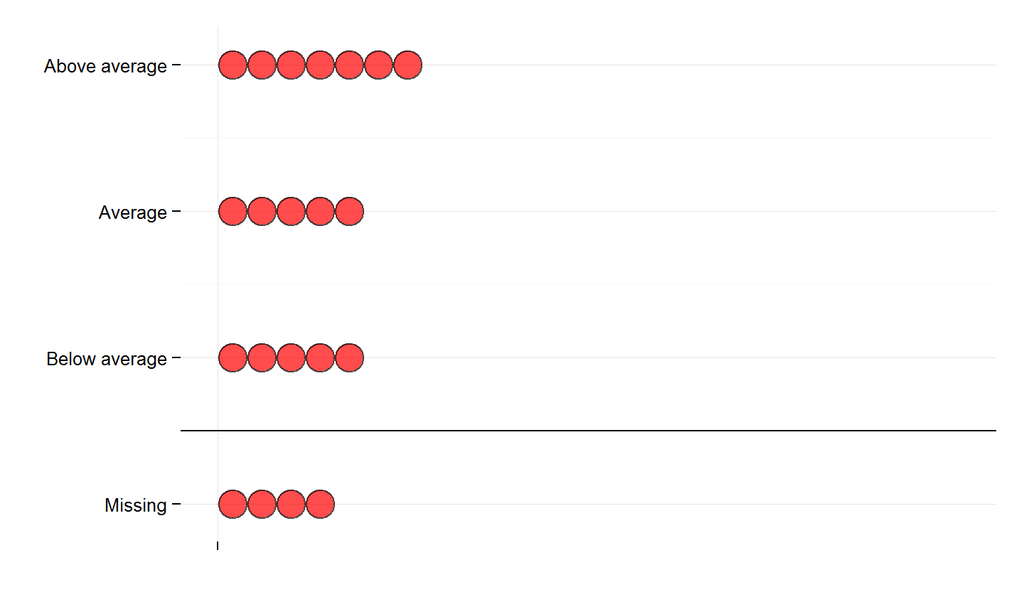

## MA1, visualization (task 3)

- Plot (and interpret) the marginal effects

## MA1, table export (task 4)

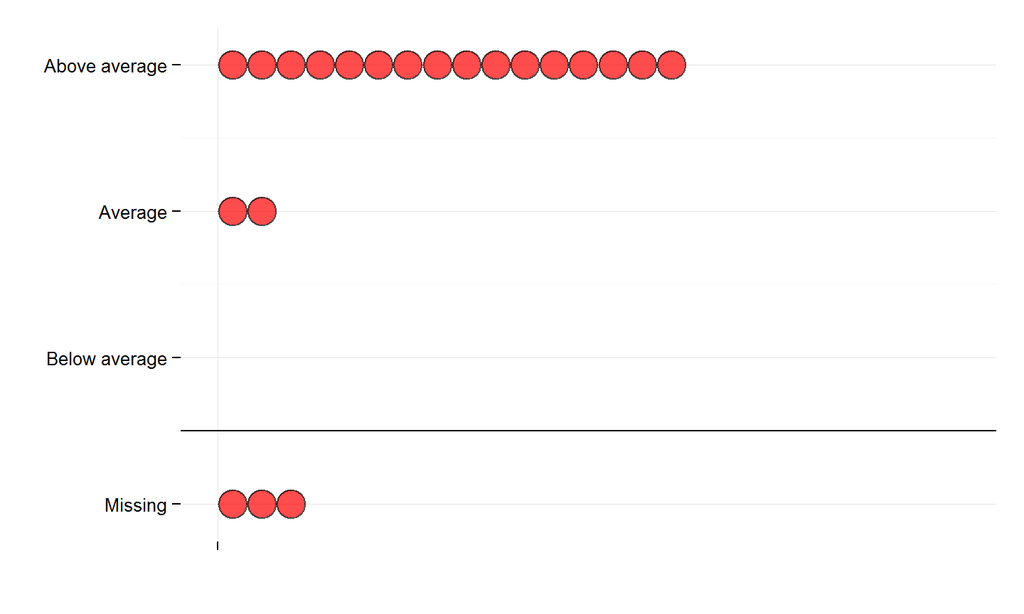

## Questions or comments?

- If not now, send me a mail.

## Tasks for lab session 2

Two tasks

1. Omitted variable bias (lecture 3)
2. Binary logistic regression (lecture 4)

## Now

- Go to BlackBoard
- Download files for `lab 2`
- Work with the tasks
- If you need help, ask.
- Work in groups or alone

## See you next week

- Questions? Mail me or feel free to stop by my office